# Final Group project

Gonzalo Vidalon, Nina Ferrer-Eriksson and Joao Pereira

2023-06-08

# 1 The problem: predicting credit card fraud

The goal of the project is to predict fraudulent credit card transactions.

We will be using a dataset with credit card transactions containing legitimate and fraud transactions. Fraud is typically well below 1% of all transactions, so a naive model that predicts that all transactions are legitimate and not fraudulent would have an accuracy of well over 99%– pretty good, no?

You can read more on credit card fraud on [Credit Card Fraud Detection Using Weighted Support Vector Machine](https://www.scirp.org/journal/paperinformation.aspx?paperid=105944)

The dataset we will use consists of credit card transactions and it includes information about each transaction including customer details, the merchant and category of purchase, and whether or not the transaction was a fraud.

## 1.1 Obtain the data

The dataset is too large to be hosted on Canvas or Github, so please download it from dropbox https://www.dropbox.com/sh/q1yk8mmnbbrzavl/AAAxzRtIhag9Nc_hODafGV2ka?dl=0 and save it in your `dsb` repo, under the `data` folder.

As we will be building a classifier model using tidymodels, there’s two things we need to do:

1. Define the outcome variable `is_fraud` as a factor, or categorical, variable, instead of the numerical 0-1 varaibles.
2. In tidymodels, the first level is the event of interest. If we leave our data as is, `0` is the first level, but we want to find out when we actually did (`1`) have a fraudulent transaction

```
## Rows: 671,028
## Columns: 14
## $ trans_date_trans_time <dttm> 2019-02-22 07:32:58, 2019-02-16 15:07:20, 2019-…
## $ trans_year            <dbl> 2019, 2019, 2019, 2019, 2019, 2019, 2019, 2020, …
## $ category              <chr> "entertainment", "kids_pets", "personal_care", "…
## $ amt                   <dbl> 7.79, 3.89, 8.43, 40.00, 54.04, 95.61, 64.95, 3.…
## $ city                  <chr> "Veedersburg", "Holloway", "Arnold", "Apison", "…
## $ state                 <chr> "IN", "OH", "MO", "TN", "CO", "GA", "MN", "AL", …
## $ lat                   <dbl> 40.1186, 40.0113, 38.4305, 35.0149, 39.4584, 32.…
## $ long                  <dbl> -87.2602, -80.9701, -90.3870, -85.0164, -106.385…
## $ city_pop              <dbl> 4049, 128, 35439, 3730, 277, 1841, 136, 190178, …
## $ job                   <chr> "Development worker, community", "Child psychoth…
## $ dob                   <date> 1959-10-19, 1946-04-03, 1985-03-31, 1991-01-28,…
## $ merch_lat             <dbl> 39.41679, 39.74585, 37.73078, 34.53277, 39.95244…
## $ merch_long            <dbl> -87.52619, -81.52477, -91.36875, -84.10676, -106…
## $ is_fraud              <fct> 0, 0, 0, 0, 0, 0, 0, 0, 0, 0, 0, 0, 0, 0, 0, 0, …
```

The data dictionary is as follows

| column(variable) | description |
| --- | --- |
| trans_date_trans_time | Transaction DateTime |
| trans_year | Transaction year |
| category | category of merchant |
| amt | amount of transaction |
| city | City of card holder |
| state | State of card holder |
| lat | Latitude location of purchase |
| long | Longitude location of purchase |
| city_pop | card holder’s city population |
| job | job of card holder |
| dob | date of birth of card holder |
| merch_lat | Latitude Location of Merchant |
| merch_long | Longitude Location of Merchant |
| is_fraud | Whether Transaction is Fraud (1) or Not (0) |

We also add some of the variables we considered in our EDA for this dataset during homework 2.

```r
card_fraud <- card_fraud %>%
  mutate( hour = hour(trans_date_trans_time),
          wday = wday(trans_date_trans_time, label = TRUE),
          month_name = month(trans_date_trans_time, label = TRUE),
          age = interval(dob, trans_date_trans_time) / years(1)
) %>%
  rename(year = trans_year) %>%

  mutate(

    # convert latitude/longitude to radians
    lat1_radians = lat / 57.29577951,
    lat2_radians = merch_lat / 57.29577951,
    long1_radians = long / 57.29577951,
    long2_radians = merch_long / 57.29577951,

    # calculate distance in miles
    distance_miles = 3963.0 * acos((sin(lat1_radians) * sin(lat2_radians)) + cos(lat1_radians) * cos(lat2_radians) * cos(long2_radians - long1_radians)),

    # calculate distance in km
    distance_km = 6377.830272 * acos((sin(lat1_radians) * sin(lat2_radians)) + cos(lat1_radians) * cos(lat2_radians) * cos(long2_radians - long1_radians))

  )
```

## 1.2 Exploratory Data Analysis (EDA)

You have done some EDA and you can pool together your group’s expertise in which variables to use as features. You can reuse your EDA from earlier, but we expect at least a few visualisations and/or tables to explore the dataset and identify any useful features.

Group all variables by type and examine each variable class by class. The dataset has the following types of variables:

1. Strings
2. Geospatial Data
3. Dates
4. Date/Times
5. Numerical

Strings are usually not a useful format for classification problems. The strings should be converted to factors, dropped, or otherwise transformed.

*Strings to Factors*

- `category`, Category of Merchant
- `job`, Job of Credit Card Holder

*Strings to Geospatial Data*

We have plenty of geospatial data as lat/long pairs, so I want to convert city/state to lat/long so I can compare to the other geospatial variables. This will also make it easier to compute new variables like the distance the transaction is from the home location.

- `city`, City of Credit Card Holder
- `state`, State of Credit Card Holder

## 1.3 Exploring factors: how is the compactness of categories?

- Do we have excessive number of categories? Do we want to combine some?

```r
card_fraud %>%
  count(category, sort=TRUE)%>%
  mutate(perc = n/sum(n))
```

```
## # A tibble: 14 × 3
##    category           n   perc
##    <chr>          <int>  <dbl>
##  1 gas_transport  68046 0.101
##  2 grocery_pos    63791 0.0951
##  3 home           63597 0.0948
##  4 shopping_pos   60416 0.0900
##  5 kids_pets      58772 0.0876
##  6 shopping_net   50743 0.0756
##  7 entertainment  48521 0.0723
##  8 food_dining    47527 0.0708
##  9 personal_care  46843 0.0698
## 10 health_fitness 44341 0.0661
## 11 misc_pos       41244 0.0615
## 12 misc_net       32829 0.0489
## 13 grocery_net    23485 0.0350
## 14 travel         20873 0.0311
```

```r
card_fraud %>%
  count(job, sort=TRUE) %>%
  mutate(perc = n/sum(n))
```

```
## # A tibble: 494 × 3
##    job                            n    perc
##    <chr>                      <int>   <dbl>
##  1 Film/video editor           5106 0.00761
##  2 Exhibition designer         4728 0.00705
##  3 Naval architect             4546 0.00677
##  4 Surveyor, land/geomatics    4448 0.00663
##  5 Materials engineer          4292 0.00640
##  6 Designer, ceramics/pottery  4262 0.00635
##  7 IT trainer                  4014 0.00598
##  8 Financial adviser           3959 0.00590
##  9 Systems developer           3948 0.00588
## 10 Environmental consultant    3831 0.00571
## # ℹ 484 more rows
```

```r
card_fraud %>%
  count(city, sort=TRUE) %>%
  mutate(perc = n/sum(n))
```

```
## # A tibble: 894 × 3
##    city            n    perc
##    <chr>       <int>   <dbl>
##  1 Birmingham   2900 0.00432
##  2 San Antonio  2645 0.00394
##  3 Utica        2633 0.00392
##  4 Phoenix      2614 0.00390
##  5 Meridian     2534 0.00378
##  6 Warren       2386 0.00356
##  7 Thomas       2375 0.00354
##  8 Conway       2362 0.00352
##  9 Cleveland    2343 0.00349
## 10 Houston      2177 0.00324
## # ℹ 884 more rows
```

```r
card_fraud %>%
  count(state, sort=TRUE) %>%
  mutate(perc = n/sum(n))
```

```
## # A tibble: 51 × 3
##    state     n   perc
##    <chr> <int>  <dbl>
##  1 TX    49266 0.0734
##  2 NY    43396 0.0647
##  3 PA    41351 0.0616
##  4 CA    29153 0.0434
##  5 OH    24095 0.0359
##  6 MI    23958 0.0357
##  7 IL    22344 0.0333
##  8 FL    22159 0.0330
##  9 AL    21121 0.0315
## 10 MO    19900 0.0297
## # ℹ 41 more rows
```

The predictors `category` and `job` are transformed into factors.

```r
card_fraud <- card_fraud %>%
  mutate(category = factor(category),
         job = factor(job))
```

`category` has 14 unique values, and `job` has 494 unique values. The dataset is quite large, with over 670K records, so these variables don’t have an excessive number of levels at first glance. However, it is worth seeing if we can compact the levels to a smaller number.

### 1.3.1 Why do we care about the number of categories and whether they are “excessive”?

Consider the extreme case where a dataset had categories that only contained one record each. There is simply insufficient data to make correct predictions using category as a predictor on new data with that category label. Additionally, if your modeling uses dummy variables, having an extremely large number of categories will lead to the production of a huge number of predictors, which can slow down the fitting. This is fine if all the predictors are useful, but if they aren’t useful (as in the case of having only one record for a category), trimming them will improve the speed and quality of the data fitting.

If I had subject matter expertise, I could manually combine categories. If you don’t have subject matter expertise, or if performing this task would be too labor intensive, then you can use cutoffs based on the amount of data in a category. If the majority of the data exists in only a few categories, then it might be reasonable to keep those categories and lump everything else in an “other” category or perhaps even drop the data points in smaller categories.

## 1.4 Do all variables have sensible types?

Consider each variable and decide whether to keep, transform, or drop it. This is a mixture of Exploratory Data Analysis and Feature Engineering, but it’s helpful to do some simple feature engineering as you explore the data. In this project, we have all data to begin with, so any transformations will be performed on the entire dataset. Ideally, do the transformations as a `recipe_step()` in the tidymodels framework. Then the transformations would be applied to any data the recipe was used on as part of the modeling workflow. There is less chance of data leakage or missing a step when you perform the feature engineering in the recipe.

## 1.5 EDA Analysis:

```r
#
card_fraud %>%
  group_by(year, is_fraud) %>%
  summarise(count=n()) %>%
  mutate(perc = count/sum(count))
```

```
## # A tibble: 4 × 4
## # Groups:   year [2]
##    year is_fraud  count    perc
##   <dbl> <fct>     <int>   <dbl>
## 1  2019 1          2721 0.00568
## 2  2019 0        475925 0.994
## 3  2020 1          1215 0.00632
## 4  2020 0        191167 0.994
```

```r
card_fraud %>%
  group_by(year, is_fraud) %>%
  summarise(money=sum(amt)) %>%
  mutate(perc = money/sum(money))
```

```
## # A tibble: 4 × 4
## # Groups:   year [2]
##    year is_fraud     money   perc
##   <dbl> <fct>        <dbl>  <dbl>
## 1  2019 1         1423140. 0.0423
## 2  2019 0        32182901. 0.958
## 3  2020 1          651949. 0.0480
## 4  2020 0        12925914. 0.952
```

Even though fraud cases only amounts for close to 0.5% of cases in each year, in terms of money this represents 4.2% and 4.8% in 2019 and 2020, respectively. Which suggest, that those few cases of fraud involve big sums of money.

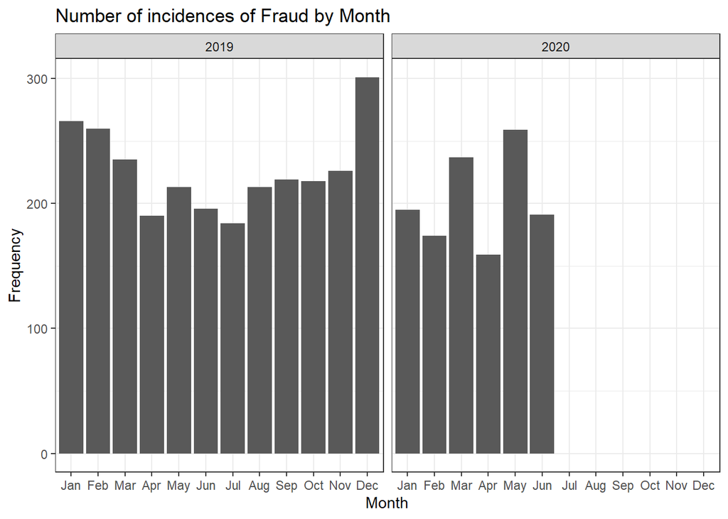

```r
#Months Distribution for 2019
card_fraud %>%
mutate(
  date_only = lubridate::date(trans_date_trans_time),
  month_name = lubridate::month(trans_date_trans_time, label=TRUE),
  hour = lubridate::hour(trans_date_trans_time),
  weekday = lubridate::wday(trans_date_trans_time, label = TRUE)
  ) %>%
  filter(is_fraud==1) %>%
  group_by(year, month_name) %>%
  summarise(count=n()) %>%
  arrange(desc(count)) %>%
  ggplot(aes(x=month_name, y=count)) +
  facet_wrap(vars(year)) +
  geom_col() +
  theme_bw() +
  labs(x = "Month", y = "Frequency", title = "Number of incidences of Fraud by Month")
```

We can see that for 2020 there is only information for January to June, which can make the comparison of fraud rates between years unfair since there may be some seasonal patterns (in December it appears to be an increase in the number of frauds)

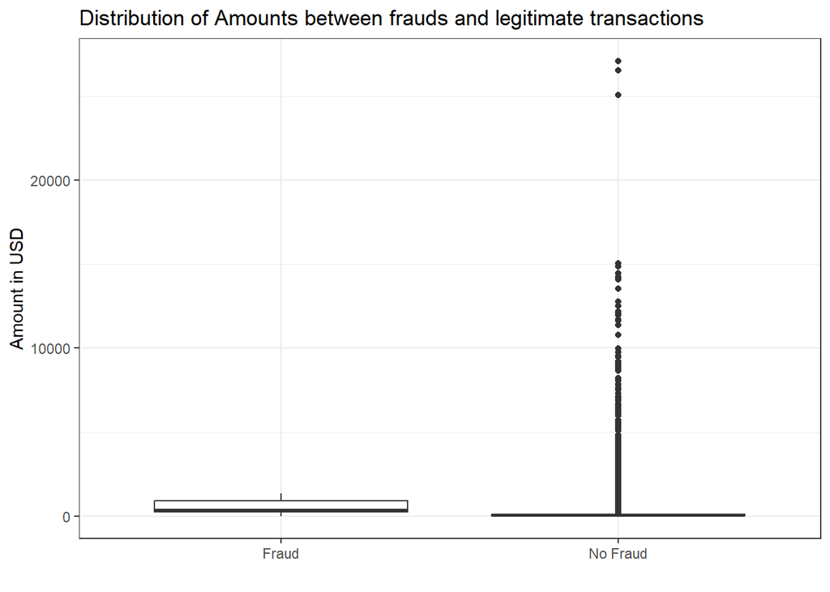

```r
card_fraud %>%
  mutate(is_fraud =
           case_when(
    is_fraud==0 ~ "No Fraud",
    is_fraud==1 ~ "Fraud",

           )) %>%
  ggplot(aes(x=is_fraud, y=amt)) +
  geom_boxplot() +
  theme_bw() +
  labs(x = "", y = "Amount in USD", title = "Distribution of Amounts between frauds and legitimate transactions")
```

```r
#It is easier this way, if you try to pivot_wider it will take much more time
card_fraud %>%
  group_by(is_fraud) %>%
  summarize(min = min(amt),
            q1 = quantile(amt, 0.25),
            median = median(amt),
            mean = mean(amt),
            q3 = quantile(amt, 0.75),
            max = max(amt))
```

```
## # A tibble: 2 × 7
##   is_fraud   min    q1 median  mean    q3    max
##   <fct>    <dbl> <dbl>  <dbl> <dbl> <dbl>  <dbl>
## 1 1         1.06 240.   369.  527.  901.   1334.
## 2 0         1      9.6   47.2  67.6  82.4 27120.
```

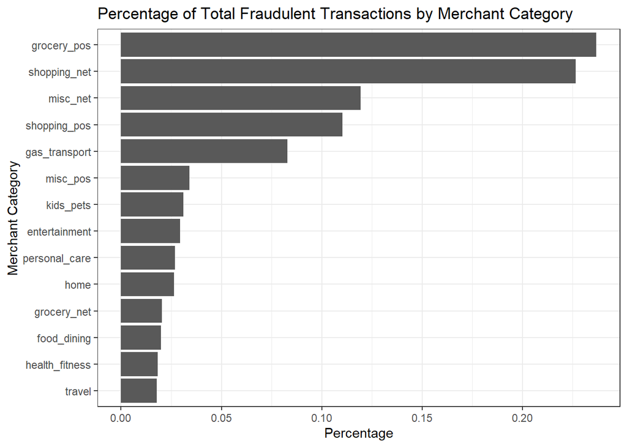

```r
card_fraud %>%
  group_by(category,is_fraud) %>%
  summarise(count=n()) %>%
  filter(is_fraud==1) %>%
  ungroup() %>%
  mutate(perc=count/sum(count)) %>%
  arrange(desc(perc)) %>%
  ggplot(aes(x=fct_reorder(category,perc), y=perc)) +
  geom_col() +
  labs(x = "Merchant Category", y = "Percentage", title = "Percentage of Total Fraudulent Transactions by Merchant Category") +
  theme(axis.text.x = element_text(angle = 45, hjust = 1)) +
  theme_bw() +
  coord_flip()
```

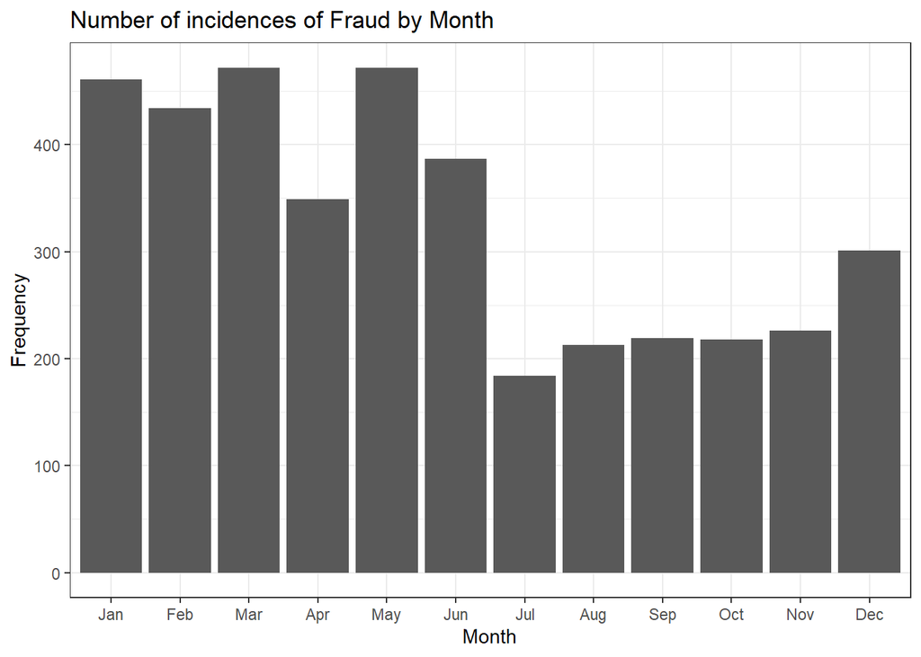

```r
#Months
card_fraud %>%
mutate(
  date_only = lubridate::date(trans_date_trans_time),
  month_name = lubridate::month(trans_date_trans_time, label=TRUE),
  hour = lubridate::hour(trans_date_trans_time),
  weekday = lubridate::wday(trans_date_trans_time, label = TRUE)
  ) %>%
  filter(is_fraud==1) %>%
  group_by(month_name) %>%
  summarise(count=n()) %>%
  arrange(desc(count)) %>%
  ggplot(aes(x=month_name, y=count)) +
  geom_col() +
  theme_bw() +
  labs(x = "Month", y = "Frequency", title = "Number of incidences of Fraud by Month")
```

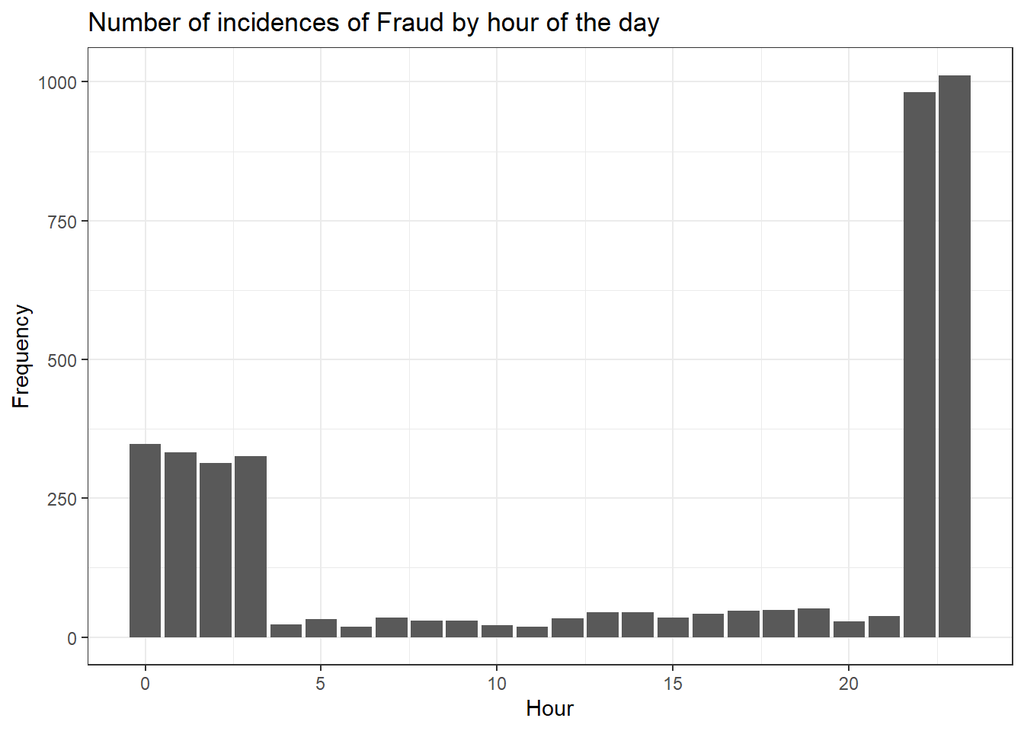

```r
#Hour
card_fraud %>%
mutate(
  date_only = lubridate::date(trans_date_trans_time),
  month_name = lubridate::month(trans_date_trans_time, label=TRUE),
  hour = lubridate::hour(trans_date_trans_time),
  weekday = lubridate::wday(trans_date_trans_time, label = TRUE)
  ) %>%
  filter(is_fraud==1) %>%
  group_by(hour) %>%
  summarise(count=n()) %>%
  arrange(desc(count)) %>%
  ggplot(aes(x=hour, y=count)) +
  geom_col() +
  theme_bw() +
  labs(x = "Hour", y = "Frequency", title = "Number of incidences of Fraud by hour of the day")
```

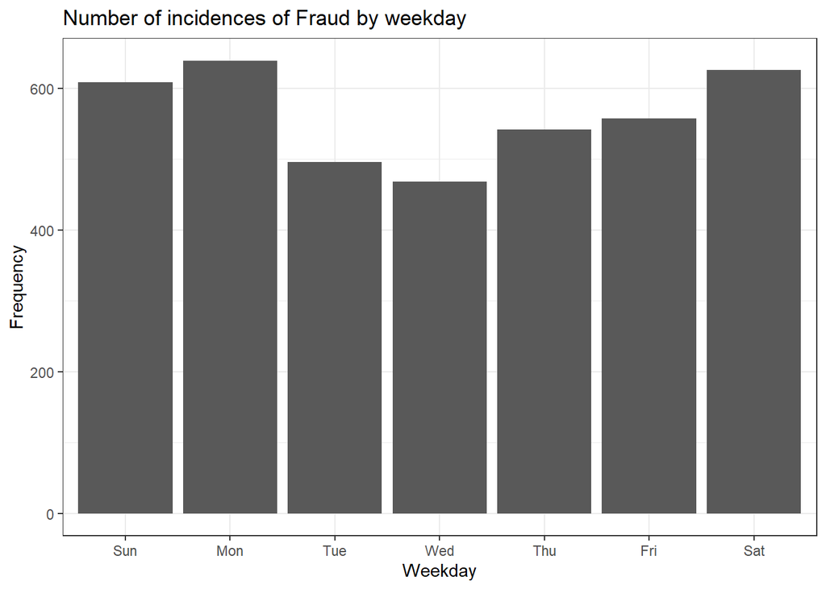

```r
#Weekday
card_fraud %>%
mutate(
  date_only = lubridate::date(trans_date_trans_time),
  month_name = lubridate::month(trans_date_trans_time, label=TRUE),
  hour = lubridate::hour(trans_date_trans_time),
  weekday = lubridate::wday(trans_date_trans_time, label = TRUE)
  ) %>%
  filter(is_fraud==1) %>%
  group_by(weekday) %>%
  summarise(count=n()) %>%
  arrange(desc(count))  %>%
  ggplot(aes(x=weekday, y=count)) +
  geom_col() +
  theme_bw() +
  labs(x = "Weekday", y = "Frequency", title = "Number of incidences of Fraud by weekday")
```

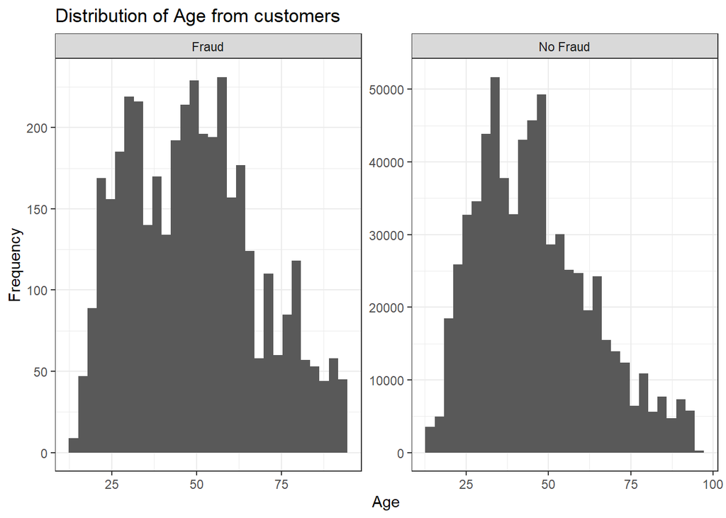

```r
card_fraud %>%
mutate(is_fraud =
           case_when(
    is_fraud==0 ~ "No Fraud",
    is_fraud==1 ~ "Fraud"),
   age = interval(dob, trans_date_trans_time) / years(1),
    ) %>%
ggplot(aes(x=age)) +
  geom_histogram() +
  facet_wrap(vars(is_fraud), scales="free") +
  theme_bw() +
    labs(x = "Age", y = "Frequency", title = "Distribution of Age from customers")
```

```r
card_fraud %>%
  group_by(is_fraud, state) %>%
  summarize(min = min(city_pop),
            q1 = quantile(city_pop, 0.25),
            median = median(city_pop),
            mean = mean(city_pop),
            q3 = quantile(city_pop, 0.75),
            max = max(city_pop),
            count=n())
```

```
## # A tibble: 101 × 9
## # Groups:   is_fraud [2]
##    is_fraud state    min     q1 median    mean     q3     max count
##    <fct>    <chr>  <dbl>  <dbl>  <dbl>   <dbl>  <dbl>   <dbl> <int>
##  1 1        AK       145    145    145    198.    239     277    17
##  2 1        AL       653   2566   8269  82139. 190178  493806   101
##  3 1        AR        37   1383   3465   5382.   5161   36438    76
##  4 1        AZ       759   1179   2872 183000. 478404 1312922    23
##  5 1        CA       104    633  35705 257029. 172817 2383912   176
##  6 1        CO        61    207  88599 156826. 389246  525713    58
##  7 1        CT       370   5438   5438   4424.   5438    5438    10
##  8 1        DC    601723 601723 601723 601723  601723  601723    12
##  9 1        DE     18799  18799  18799  18799   18799   18799     7
## 10 1        FL       217  33804 139650 166044. 237282  717255   142
## # ℹ 91 more rows
```

[figure not shown]

```r
card_fraud %>%
  mutate(is_fraud =
           case_when(
    is_fraud==0 ~ "No Fraud",
    is_fraud==1 ~ "Fraud",

           )) %>%
  ggplot(aes(x=is_fraud, y=city_pop)) +
  geom_boxplot() +
  theme_bw() +
  facet_wrap(vars(state)) +
  labs(x = "", y = "Distance in km.", title = "Distribution of the distance and fraudness")
```

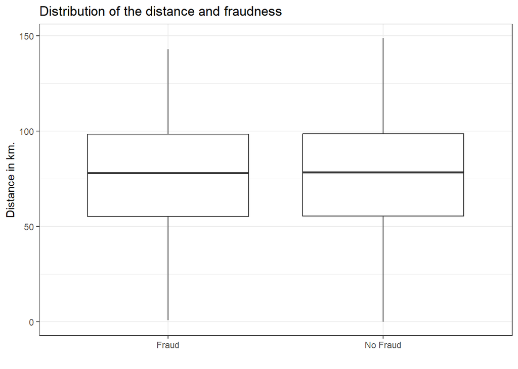

```r
card_fraud %>%
  mutate(is_fraud =
           case_when(
    is_fraud==0 ~ "No Fraud",
    is_fraud==1 ~ "Fraud",

           )) %>%
  ggplot(aes(x=is_fraud, y=distance_km)) +
  geom_boxplot() +
  theme_bw() +
  labs(x = "", y = "Distance in km.", title = "Distribution of the distance and fraudness")
```

## 1.6 Which variables to keep in your model?

You have a number of variables and you have to decide which ones to use in your model. For instance, you have the latitude/lognitude of the customer, that of the merchant, the same data in radians, as well as the `distance_km` and `distance_miles`. Do you need them all?

No, we only need the distance in one measure and for simplicity we will go with distance in km. Same for latitude and longidute, we will only consider one of the measures.

We go for city_pop instead of using both city_pop and state because of high multicolinearity between those variables and number of estimators that “state” variable would need.

```r
card_fraud_1 <- card_fraud %>%
mutate(age = interval(dob, trans_date_trans_time) / years(1)) %>%
  select(category, amt, city_pop, is_fraud, wday, month_name, age, distance_km, hour)
```

## 1.7 Fit your workflows in smaller sample

You will be running a series of different models, along the lines of the California housing example we have seen in class. However, this dataset has 670K rows and if you try various models and run cross validation on them, your computer may slow down or crash.

Thus, we will work with a smaller sample of 10% of the values the original dataset to identify the best model, and once we have the best model we can use the full dataset to train- test our best model.

```r
# select a smaller subset
my_card_fraud <- card_fraud_1 %>%
  # select a smaller subset, 10% of the entire dataframe
  slice_sample(prop = 0.10)
```

## 1.8 Split the data in training - testing

```r
# **Split the data**

set.seed(123)

data_split <- initial_split(my_card_fraud, # updated data
                           prop = 0.8,
                           strata = is_fraud)

card_fraud_train <- training(data_split)
card_fraud_test <- testing(data_split)
```

## 1.9 Cross Validation

Start with 3 CV folds to quickly get an estimate for the best model and you can increase the number of folds to 5 or 10 later.

```r
set.seed(123)
cv_folds <- vfold_cv(data = card_fraud_train,
                          v = 3,
                          strata = is_fraud)
cv_folds
```

```
## #  3-fold cross-validation using stratification
## # A tibble: 3 × 2
##   splits                id
##   <list>                <chr>
## 1 <split [35787/17894]> Fold1
## 2 <split [35787/17894]> Fold2
## 3 <split [35788/17893]> Fold3
```

## 1.10 Define a tidymodels `recipe`

What steps are you going to add to your recipe? Do you need to do any log transformations?

```r
fraud_rec <- recipe(is_fraud ~ ., data = card_fraud_train) %>%
  step_log(amt, city_pop, age, distance_km) %>%
  step_naomit(everything(), skip=TRUE) %>%
  step_novel(all_nominal(), -all_outcomes()) %>%
  step_normalize(all_numeric(), -all_outcomes()) %>%
  step_dummy(all_nominal(), -all_outcomes()) %>%
  step_zv(all_numeric(), -all_outcomes())
```

Once you have your recipe, you can check the pre-processed dataframe

```r
prepped_data <-
  fraud_rec %>% # use the recipe object
  prep() %>% # perform the recipe on training data
  juice() # extract only the preprocessed dataframe

glimpse(prepped_data)
```

```
## Rows: 53,681
## Columns: 38
## $ amt                     <dbl> 2.279579456, -1.908385698, 0.716527069, 1.0726…
## $ city_pop                <dbl> -0.75343567, -0.02213422, 0.80856396, -0.82464…
## $ age                     <dbl> 0.56924856, -0.05364752, -1.58412127, 1.878870…
## $ distance_km             <dbl> 0.041315428, 0.311109207, -1.295257084, -0.067…
## $ hour                    <dbl> -0.55669549, 0.47346148, 1.35645317, 1.0621226…
## $ is_fraud                <fct> 0, 0, 0, 0, 0, 0, 0, 0, 0, 0, 0, 0, 0, 0, 0, 0…
## $ category_food_dining    <dbl> 0, 0, 0, 0, 0, 1, 0, 0, 0, 0, 0, 0, 0, 0, 0, 0…
## $ category_gas_transport  <dbl> 0, 0, 0, 0, 0, 0, 1, 0, 0, 0, 0, 0, 0, 0, 0, 0…
## $ category_grocery_net    <dbl> 0, 0, 0, 0, 0, 0, 0, 0, 0, 0, 0, 1, 0, 0, 0, 0…
## $ category_grocery_pos    <dbl> 0, 0, 1, 0, 0, 0, 0, 0, 1, 0, 0, 0, 0, 0, 0, 0…
## $ category_health_fitness <dbl> 0, 0, 0, 0, 0, 0, 0, 0, 0, 1, 0, 0, 0, 0, 0, 0…
## $ category_home           <dbl> 0, 0, 0, 0, 0, 0, 0, 1, 0, 0, 0, 0, 0, 0, 1, 0…
## $ category_kids_pets      <dbl> 0, 0, 0, 1, 0, 0, 0, 0, 0, 0, 1, 0, 0, 1, 0, 0…
```

[output cut: 25 more lines]

```r
prepped_data %>%
  group_by(wday_1) %>%
  summarise(count=n())
```

```
## # A tibble: 7 × 2
##    wday_1 count
##     <dbl> <int>
## 1 -0.540  10236
## 2 -0.386  10425
## 3 -0.231   6631
## 4 -0.0772  5492
## 5  0.0772  6074
## 6  0.231   6359
## 7  0.386   8464
```

## 1.11 Define various models

You should define the following classification models:

1. Logistic regression, using the `glm` engine
2. Decision tree, using the `C5.0` engine
3. Random Forest, using the `ranger` engine and setting `importance = "impurity"`)
4. A boosted tree using Extreme Gradient Boosting, and the `xgboost` engine
5. A k-nearest neighbours, using 4 nearest_neighbors and the `kknn` engine

```r
## Model Building

# 1. Pick a `model type`
# 2. set the `engine`
# 3. Set the `mode`:  classification

# Logistic regression
log_spec <-  logistic_reg() %>%  # model type
  set_engine(engine = "glm") %>%  # model engine
  set_mode("classification") # model mode

# Decision Tree
tree_spec <- decision_tree() %>%
  set_engine(engine = "C5.0") %>%
  set_mode("classification")

rf_spec <-
  rand_forest() %>%
  set_engine("ranger", importance = "impurity") %>%
  set_mode("classification")

xgb_spec <-
  boost_tree() %>%
  set_engine("xgboost") %>%
  set_mode("classification")

# K-nearest neighbour (k-NN)
knn_spec <-
  nearest_neighbor(neighbors = 4) %>% # we can adjust the number of neighbors
  set_engine("kknn") %>%
  set_mode("classification")
```

## 1.12 Bundle recipe and model with `workflows`

```r
## Bundle recipe and model with `workflows`


log_wflow <- # new workflow object
 workflow() %>% # use workflow function
 add_recipe(fraud_rec) %>%   # use the new recipe
 add_model(log_spec)   # add your model spec

## A few more workflows

tree_wflow <-
 workflow() %>%
 add_recipe(fraud_rec) %>%
 add_model(tree_spec)

rf_wflow <-
 workflow() %>%
 add_recipe(fraud_rec) %>%
 add_model(rf_spec)

xgb_wflow <-
 workflow() %>%
 add_recipe(fraud_rec) %>%
 add_model(xgb_spec)

knn_wflow <-
 workflow() %>%
 add_recipe(fraud_rec) %>%
 add_model(knn_spec)
```

## 1.13 Fit models

You may want to compare the time it takes to fit each model. `tic()` starts a simple timer and `toc()` stops it

```r
tic()
log_res <- log_wflow %>%
  fit_resamples(
    resamples = cv_folds,
    metrics = metric_set(
      recall, precision, f_meas, accuracy,
      kap, roc_auc, sens, spec),
    control = control_resamples(save_pred = TRUE))
```

```
## → A | warning: prediction from rank-deficient fit; attr(*, "non-estim") has doubtful cases
```

[output not shown]

```r
time <- toc()
```

```
## 4.98 sec elapsed
```

```r
log_time <- time[[4]]

tic()
tree_res <- tree_wflow %>%
  fit_resamples(
    resamples = cv_folds,
    metrics = metric_set(
      recall, precision, f_meas, accuracy,
      kap, roc_auc, sens, spec),
    control = control_resamples(save_pred = TRUE))
time <- toc()
```

```
## 21.53 sec elapsed
```

```r
tree_time <- time[[4]]

tic()
rf_res <- rf_wflow %>%
  fit_resamples(
    resamples = cv_folds,
    metrics = metric_set(
      recall, precision, f_meas, accuracy,
      kap, roc_auc, sens, spec),
    control = control_resamples(save_pred = TRUE))
time <- toc()
```

```
## 37.13 sec elapsed
```

```r
rf_time <- time[[4]]

tic()
xgb_res <- xgb_wflow %>%
  fit_resamples(
    resamples = cv_folds,
    metrics = metric_set(
      recall, precision, f_meas, accuracy,
      kap, roc_auc, sens, spec),
    control = control_resamples(save_pred = TRUE))
time <- toc()
```

```
## 4.12 sec elapsed
```

```r
xgb_time <- time[[4]]

tic()
knn_res <- knn_wflow %>%
  fit_resamples(
    resamples = cv_folds,
    metrics = metric_set(
      recall, precision, f_meas, accuracy,
      kap, roc_auc, sens, spec),
    control = control_resamples(save_pred = TRUE))
time <- toc()
```

```
## 214.64 sec elapsed
```

```r
knn_time <- time[[4]]
```

## 1.14 Compare models

```r
## Model Comparison

log_metrics <-
  log_res %>%
  collect_metrics(summarise = TRUE) %>%
  # add the name of the model to every row
  mutate(model = "Logistic Regression",
         time = log_time)

# add mode models here

tree_metrics <-
  tree_res %>%
  collect_metrics(summarise = TRUE) %>%
  mutate(model = "Decision Tree")

rf_metrics <-
  rf_res %>%
  collect_metrics(summarise = TRUE) %>%
  mutate(model = "Random Forest")

xgb_metrics <-
  xgb_res %>%
  collect_metrics(summarise = TRUE) %>%
  mutate(model = "XGBoost")

knn_metrics <-
  knn_res %>%
  collect_metrics(summarise = TRUE) %>%
  mutate(model = "Knn")


# create dataframe with all models
model_compare <- bind_rows(log_metrics,
                            tree_metrics,
                            rf_metrics,
                           xgb_metrics,
                           knn_metrics
                      ) %>%
  # get rid of 'sec elapsed' and turn it into a number
  mutate(time = str_sub(time, end = -13) %>%
           as.double()
         )
```

```r
model_compare
```

```
## # A tibble: 40 × 8
##    .metric   .estimator  mean     n  std_err .config              model     time
##    <chr>     <chr>      <dbl> <int>    <dbl> <chr>                <chr>    <dbl>
##  1 accuracy  binary     0.995     3 0.000401 Preprocessor1_Model1 Logisti…  4.98
##  2 f_meas    binary     0.214     3 0.0385   Preprocessor1_Model1 Logisti…  4.98
##  3 kap       binary     0.213     3 0.0384   Preprocessor1_Model1 Logisti…  4.98
##  4 precision binary     0.702     3 0.0912   Preprocessor1_Model1 Logisti…  4.98
##  5 recall    binary     0.128     3 0.0245   Preprocessor1_Model1 Logisti…  4.98
##  6 roc_auc   binary     0.851     3 0.00771  Preprocessor1_Model1 Logisti…  4.98
##  7 sens      binary     0.128     3 0.0245   Preprocessor1_Model1 Logisti…  4.98
##  8 spec      binary     1.00      3 0.000135 Preprocessor1_Model1 Logisti…  4.98
##  9 accuracy  binary     0.997     3 0.000261 Preprocessor1_Model1 Decisio… NA
## 10 f_meas    binary     0.654     3 0.0261   Preprocessor1_Model1 Decisio… NA
## # ℹ 30 more rows
```

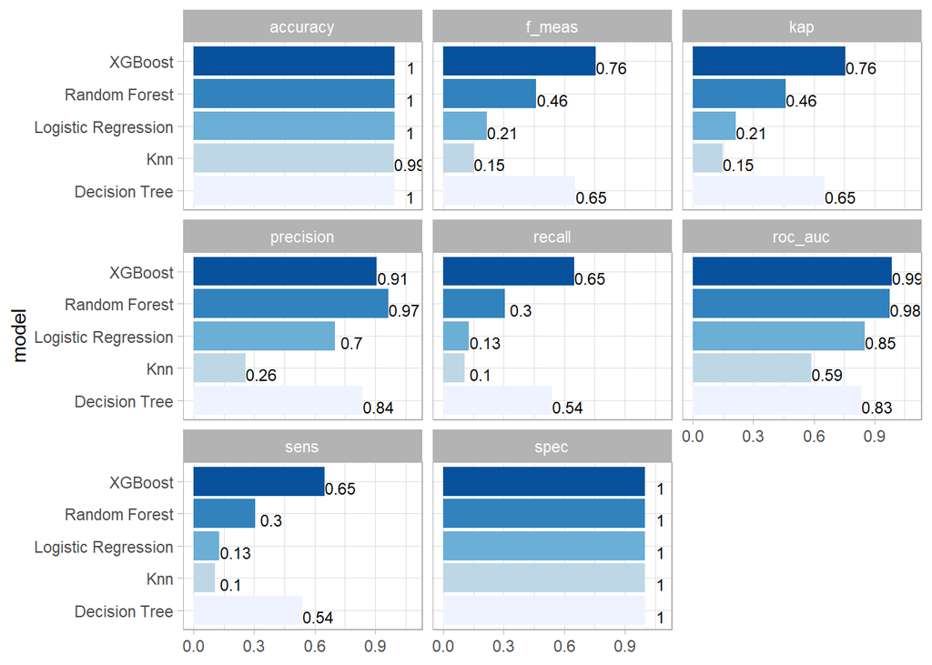

```r
model_compare %>%
  ggplot(aes(model, mean, fill=model)) +
  geom_col() +
  facet_wrap(vars(.metric)) +
  coord_flip() +
  scale_fill_brewer(palette = "Blues") +
   geom_text(
     size = 3,
     aes(label = round(mean, 2),
         y = mean + 0.08),
     vjust = 1
  )+
  theme_light()+
  theme(legend.position = "none")+
  labs(y = NULL)
```

## 1.15 Which metric to use

This is a highly imbalanced data set, as roughly 99.5% of all transactions are ok, and it’s only 0.5% of transactions that are fraudulent. A `naive` model, which classifies everything as ok and not-fraud, would have an accuracy of 99.5%, but what about the sensitivity, specificity, the AUC, etc?

Explanation:

When dealing with imbalanced datasets, accuracy alone is not a reliable metric to evaluate model performance. Due to the disproportionate class distribution, a model that simply predicts the majority class (in this case, “Not Fraud”) would achieve a high accuracy but fail to detect the minority class (fraudulent transactions).

Here’s a brief explanation of the metrics you mentioned and their suitability for imbalanced datasets:

Sensitivity/Recall: Sensitivity, also known as recall or true positive rate, measures the ability of a model to correctly identify positive instances (fraudulent transactions). It is a crucial metric when the goal is to minimize false negatives (missing fraudulent transactions). Higher sensitivity is desirable in fraud detection scenarios.

With a little help from ChatGPT we learn why other measures were not accurate for this case:

Specificity: While specificity is important to measure the model’s ability to correctly identify negative instances (non-fraudulent transactions), it may not be the best metric when the cost of false positives is high, as it doesn’t prioritize minimizing false negatives (missing fraudulent transactions).

Precision: Precision is useful to assess the proportion of correctly identified positive instances (fraudulent transactions) out of all instances predicted as positive, but it may not capture the full picture when the focus is on minimizing false negatives, as it doesn’t consider the false negatives in its calculation.

F1 Score: The F1 score provides a balance between precision and recall, but it doesn’t provide separate insights into the true positive and true negative rates, which can be valuable in fraud detection scenarios.

ROC AUC: While ROC AUC is a useful metric to evaluate the model’s ability to distinguish between classes, it may not directly address the specific requirements of minimizing false negatives or false positives, as it summarizes the overall performance across all possible thresholds and doesn’t focus on specific trade-offs between sensitivity and specificity.

## 1.16 `last_fit()`

```r
## `last_fit()` on test set

# - `last_fit()`  fits a model to the whole training data and evaluates it on the test set.
# - provide the workflow object of the best model as well as the data split object (not the training data).

last_fit_xgb <- last_fit(xgb_wflow,
                        split = data_split,
                        metrics = metric_set(
                          accuracy, f_meas, kap, precision,
                          recall, roc_auc, sens, spec))

last_fit_xgb %>% collect_metrics(summarize = TRUE)
```

```
## # A tibble: 8 × 4
##   .metric   .estimator .estimate .config
##   <chr>     <chr>          <dbl> <chr>
## 1 accuracy  binary         0.998 Preprocessor1_Model1
## 2 f_meas    binary         0.766 Preprocessor1_Model1
## 3 kap       binary         0.765 Preprocessor1_Model1
## 4 precision binary         0.925 Preprocessor1_Model1
## 5 recall    binary         0.653 Preprocessor1_Model1
## 6 sens      binary         0.653 Preprocessor1_Model1
## 7 spec      binary         1.00  Preprocessor1_Model1
## 8 roc_auc   binary         0.977 Preprocessor1_Model1
```

## 1.17 Get variable importance using `vip` package

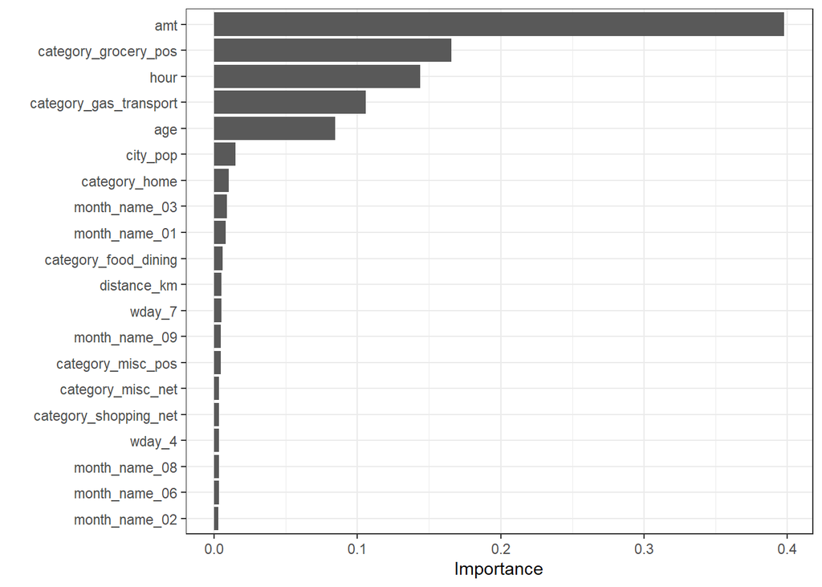

```r
last_fit_xgb %>%
  pluck(".workflow", 1) %>%
  pull_workflow_fit() %>%
  vip(num_features = 20) +
  theme_bw()
```

## 1.18 Plot Final Confusion matrix and ROC curve

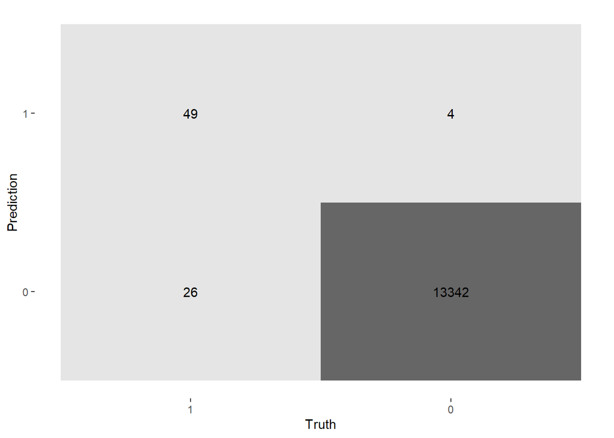

```r
## Final Confusion Matrix

last_fit_xgb %>%
  collect_predictions() %>%
  conf_mat(is_fraud, .pred_class) %>%
  autoplot(type = "heatmap")
```

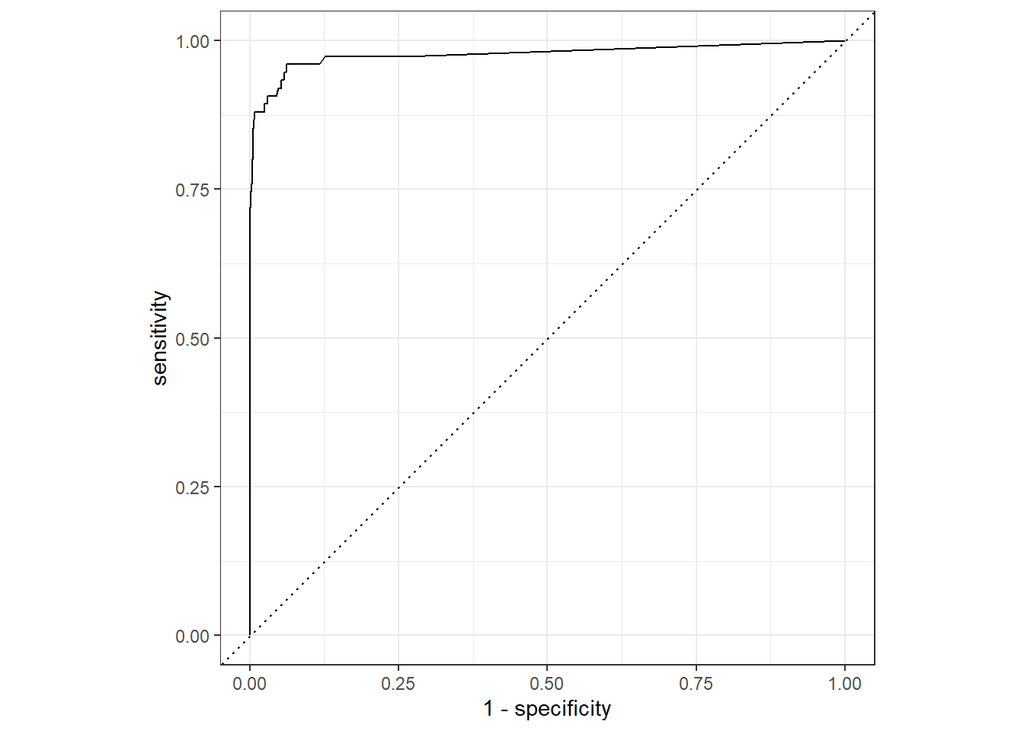

```r
## Final ROC curve
last_fit_xgb %>%
  collect_predictions() %>%
  roc_curve(is_fraud, .pred_1) %>%
  autoplot()
```

## 1.19 Calculating the cost of fraud to the company

- How much money (in US$ terms) are fraudulent transactions costing the company? Generate a table that summarizes the total amount of legitimate and fraudulent transactions per year and calculate the % of fraudulent transactions, in US$ terms. Compare your model vs the naive classification that we do not have any fraudulent transactions.

```r
best_model_preds <-
  xgb_wflow %>%
  fit(data = card_fraud_train) %>%

  ## Use `augment()` to get predictions for entire data set
  augment(new_data = card_fraud_1)

best_model_preds %>%
  conf_mat(truth = is_fraud, estimate = .pred_class)
```

```
##           Truth
## Prediction      1      0
##          1   2630    268
##          0   1306 666824
```

```r
cost <- best_model_preds %>%
  select(is_fraud, amt, pred = .pred_class)

cost <- cost %>%
  mutate(

  # naive false-- we think every single transaction is ok and not fraud
  naive_false = ifelse(is_fraud == 1, amt, 0),                     # naive false


  # false negatives-- we thought they were not fraud, but they were
  false_negatives = ifelse(is_fraud == 1 & pred == 0, amt, 0),    # false negatives


  # false positives-- we thought they were fraud, but they were not
  false_positives = ifelse(is_fraud == 0 & pred == 1, amt, 0),    # false positives


  # true positives-- we thought they were fraud, and they were
  true_positives = ifelse(is_fraud == 1 & pred == 1, amt, 0),  # true positives



  # true negatives-- we thought they were ok, and they were
  true_negatives = ifelse(is_fraud == 0 & pred == 0, amt, 0)        # true negatives

)

# Summarising

cost_summary <- cost %>%
  summarise(across(starts_with(c("false","true", "amt", "naive")),
            ~ sum(.x, na.rm = TRUE)))

cost_summary
```

```
## # A tibble: 1 × 6
##   false_negatives false_positives true_positives true_negatives       amt
##             <dbl>           <dbl>          <dbl>          <dbl>     <dbl>
## 1         467952.         310087.       1607138.      44798728. 47183904.
## # ℹ 1 more variable: naive_false <dbl>
```

- How much money (in US$ terms) are fraudulent transactions costing the company? Generate a table that summarizes the total amount of legitimate and fraudulent transactions per year and calculate the % of fraudulent transactions, in US$ terms. Compare your model vs the naive classification that we do not have any fraudulent transactions.

```r
cost %>%
  group_by(is_fraud) %>%
  summarise(sum=sum(amt)) %>%
  mutate(perc=sum/sum(sum))
```

```
## # A tibble: 2 × 3
##   is_fraud       sum   perc
##   <fct>        <dbl>  <dbl>
## 1 1         2075089. 0.0440
## 2 0        45108815. 0.956
```

```r
cost_summary %>%
  mutate(total_cost=false_negatives+0.02*false_positives,
    cost_perc = total_cost/amt,
         ) %>%
  select(total_cost, cost_perc)
```

```
## # A tibble: 1 × 2
##   total_cost cost_perc
##        <dbl>     <dbl>
## 1    474153.    0.0100
```

```r
#Naive Guess Cost
scales::dollar(cost_summary$naive_false)
```

```
## [1] "$2,075,089"
```

```r
#XGBoost Cost
scales::dollar(cost_summary$false_negatives + cost_summary$false_positives * 0.02)
```

```
## [1] "$474,153"
```

```r
#Gain by using our model instead of the naive guess
scales::dollar(cost_summary$naive_false - cost_summary$false_negatives - cost_summary$false_positives * 0.02)
```

```
## [1] "$1,600,936"
```